# LAPTOP ANALYSIS

## by Terri-Lee Meyer

## Investigation Overview

Laptops are made up of features that can be make or break it in the market. It is a great question if these specifications contribute greatly to the price and weight of the laptop or determining the overall performance for the user. The overall features of a laptop could in return affect each other - making a balance to be desired in order to find that goldilocks area in the perfect laptop for each category.There are a great number of specifications to consider when choosing a laptop. However, the focus on this presentation will be put of the categorisation of laptops, CPU speed, RAM size and screen type.

## Dataset Overview

The dataset initially contained 1303 observations with 13 columns. There are 17 columns with 1043 observations after cleaning to make the dataset usable for my analysis. The feature columns crucial to this presentation include weight, price, CPU and GPU processors, RAM size, Screen Size and laptop category.

## RAM Size:

RAM Size is an important quality in a laptop. RAM helps to keeps track of any apps running in the background and allows you quickly jump back to where you left off on each of them. Without enough RAM, your laptop will be slow to respond. Let's compare RAM sizes to their effect on price, weight and CPU speed and by extension how RAM sizes are distributed across laptop categories.

### RAM Size Effects on Price, Weight & CPU Speed:

There is more denstity for the lower prices given RAM sizes and there are slight increases in the minimum prices as the RAM increase. Not directly influential of the price as the price can still vary for each RAM size. The weight of a laptop is dependant on the size of the RAM. The higher the RAM, the higher the weight typically will be for the laptop. The RAM of a laptop works hand in hand with the CPU speed. They both help the laptop control processes at a faster rate if the RAM is higher. CPU Speeds are cautiously influenced by the RAM size. RAM sizes of 6GB and higher commonly have a CPU speed range of 1.5GHz to 3.0 GHz. 8GB RAM laptops can range from as low as 1GHz. 24GB and higher RAM sizes have CPU Speeds higher than 2.5GHz.

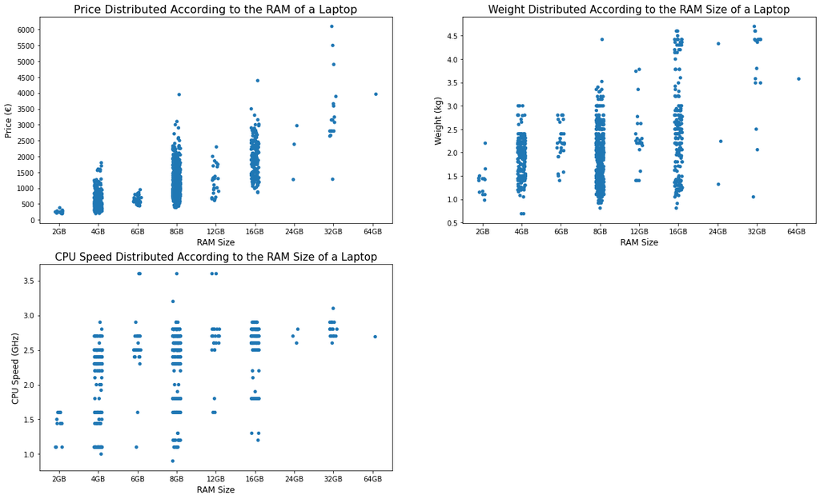

### RAM Size vs Laptop Category:

The most ideal RAM Size to use per Laptop Category Notebooks: 8GB Netbooks: 4GB 2 In 1 Convertibles: 8GB Ultrabooks: 8GB Gaming: 16GB Workstation: 8GB

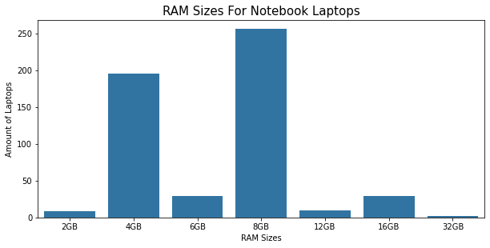

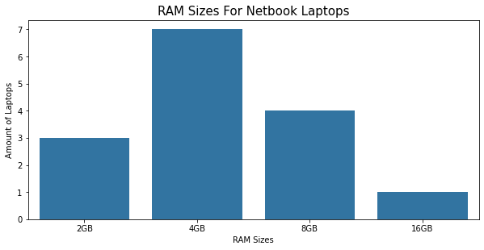

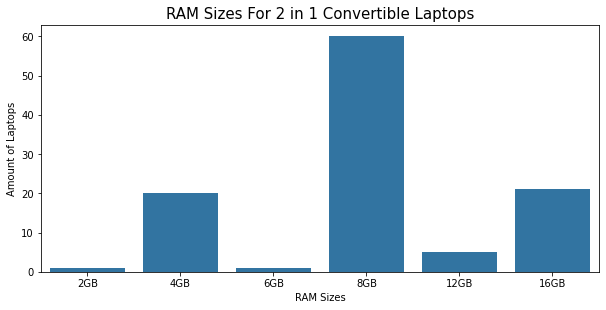

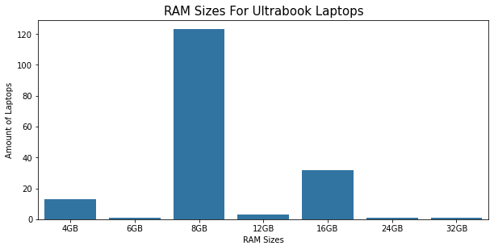

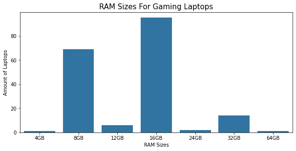

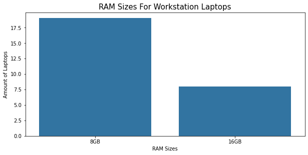

## Screen Size:

Screen size is a preferential component to a laptop that will vary from user to user. Each type of laptop will accommodate the optimal screen size to fit the user's function in the category.

### Screen Size vs Laptop Category:

Below presents count plots illustrating the distribution of screen sizes for each laptop category. Notebooks, 2 In 1 Convertibles and Ultrabooks have a wide variety of screen sizes.

The most ideal Screen Size(s) to use per Laptop Category:

- Notebook: 15.6"
- Netbook: 11.6" and 12.5"
- 2 In 1 Convertible: 13.3"
- Ultrabook: 13.3" and 14.0"
- Gaming: 15.6" and 17.3"
- Workstation: 15.6"

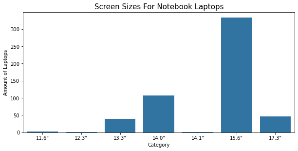

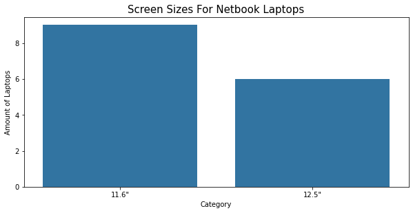

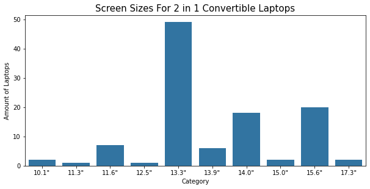

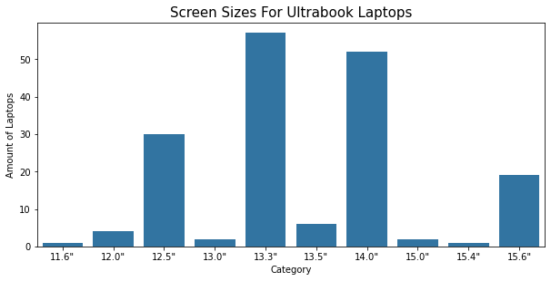

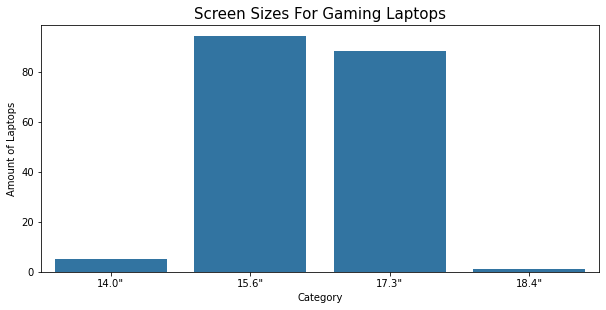

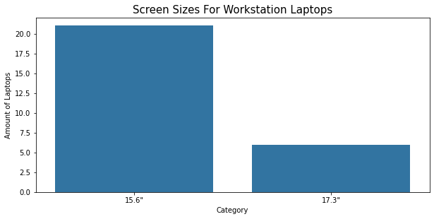

### Screen Size vs Price:

Choosing the best screen size comes from the functionality of user of the laptop but let's see how it will affect the weight and price of the laptop too. There is an impact on both price weight similarly. Generally as the screen size increases, this will increase price and weight of a laptops with exceptions from 11.6", 12.3" and 14.1" laptops.

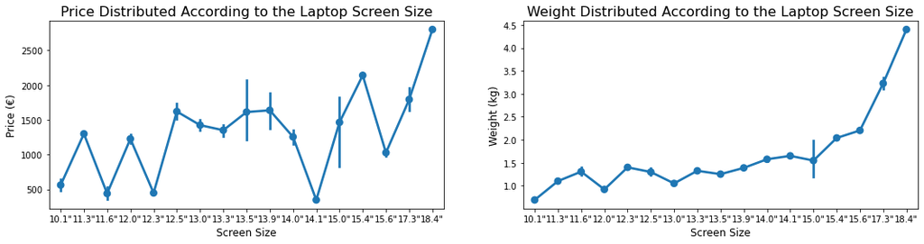

### Laptop Category vs CPU Brand:

When looking at the best CPU for a laptop, comparing the laptop categories will bring a good sense on the brand you would be most ideal for the niche. AMD CPUs are only used in notebook and gaming laptops and are used in cheaper laptops than most Intel CPU laptops. In contrast Intel CPUs have the versality of being present in all categories.

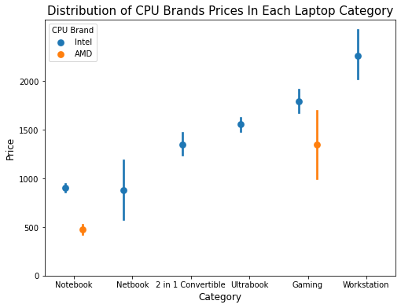

## Laptop Category:

It is interesting to see how the types of laptops are produced to fit a target market. One noteable distinguishment is that Notebooks dominate the market making up half of all laptops.

[figure not shown]

### Laptop Category vs Price:

Notebooks and Netbooks have similar prices ranges but Netbooks have a lower median - they will more likely have lower prices. Notebooks and 2 In 1 Convertibles vary greatly in prices. Notebook laptops lowest price is €196 and highest price is €4899. 2 In 1 Convertible laptops lowest price is €275 and highest price is €2824. All Netbooks are lower than €2000. Gaming and Workstation laptops are commonly priced higher than other categories with Gaming laptops contributing to the highest price with the Razer Brand laptop.

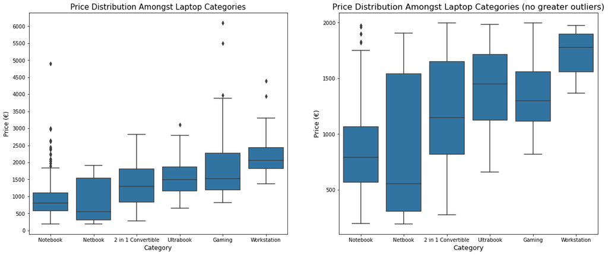

### Laptop Category vs Weight & CPU Speed:

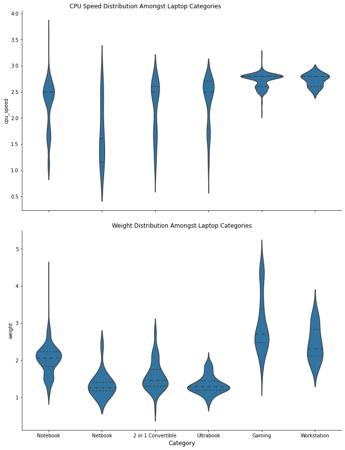